# Features Summary

Javad Khataei

9/04/2019

In this markdown, we use **x, y, z Counts** variables to created new features and then we have a look at the **Mean** and **Standard devation** of the features.

## Generating Features

### Read and prepare the data

```r
#import libraries
library(data.table)
library(tidyverse)
library(lubridate)
library(activityCounts)
library(magrittr)
library(scales)
library(caret)
library(stringr)
library(MLmetrics)
library(PRROC)
library(gridExtra)
library(kableExtra)
library(imputeTS)
library(Beap) # It's not on CRAN yet





# ---------------------------- Read the data ----------------------

# set the working directory to the folder that has the raw data and the intervals file
OS <- Sys.info()
if (OS["sysname"] == "Windows") {
  main_path <-
    "Z:/Research/dfuller/Walkabilly/studies/smarphone_accel/data"
} else {
  main_path <-
    "/Volumes/hkr-storage/Research/dfuller/Walkabilly/studies/smarphone_accel/data"
}

# Read the file with x,y,z axis and labels.
Ethica_df <-
  fread(paste0(main_path,"/Ethica_Jaeger_Merged/pocket/pocket_with_couns_and_vec_meg_not_duplicated.csv"))


# ---------------------------- Prepare the data ----------------------------

# Participants 112 , 121 .122 , and 132 are not properly classified
working_df  <-
  Ethica_df %>% filter(!(participant_id %in% c(112, 121, 122, 132)))

# Model A_1 only uses raw accel data
working_df %<>%  dplyr::select(c(x, y, z, counts_vec_mag, participant_id, trimmed_activity))
working_df  %<>% filter(trimmed_activity != "transit")


# models canot work with strin
working_df$trimmed_activity  %<>% str_replace_all(" ", "_") %>%
  factor(
    levels = c(
      "Lying",
      "Sitting",
      "Self_Pace_walk",
      "Running_3_METs",
      "Running_5_METs",
      "Running_7_METs"
    )
  )

working_df  %<>% na.omit()
```

Note that we need to exclude Participants number 112 , 121 .122 , and 132 as they are not properly classified. Also, to save time, we run the models on some of the data. Check the code for more details.

### Generate new features

We use the function ``GenerateFeatures` from the `Beap` package to create new features for `x`, `y`, and `z` counts. Then we apply the models. The window is set to 2 seconds. The Counts frequency is 1 Hz.

```r
frequency <- 1 # freq of new data which is counts not raw x,y,z axis
window_size_sec <- 2
# The number of features reduces by this
reduction_coef <-  window_size_sec * frequency
new_features_df <-
  GenerateFeatures(raw_df = working_df,
                   window_size_sec = window_size_sec,
                   frequency = frequency)
# Increase the frequency
new_features_df <-
  new_features_df[rep(1:nrow(new_features_df) , each = reduction_coef),]


# reduce the size of working_df to add new_features
working_df  %<>% slice(1:nrow(new_features_df))

working_df <- bind_cols(working_df, new_features_df)
# some models cannpt train if there is any NA
working_df  %<>% na_interpolation(option =  "linear")
```

## Calculate Mean for each participant

```r
working_df %>% group_by(participant_id) %>%
        select(-c(trimmed_activity)) %>%
    summarise_all(mean) %>%
    kable(label = " Features SD for each participant") %>%
    kable_styling(full_width = T, bootstrap_options = c("striped", "hover", "responsive")) %>%
    scroll_box(width = "100%", height = "600px")
```

| participant_id | x | y | z | counts_vec_mag | sum_x | sum_y | sum_z | snp_x | snp_y | snp_z | mean_x | mean_y | mean_z | sd_x | sd_y | sd_z | cv_x | cv_y | cv_z | amp_x | amp_y | amp_z | iqr_x | iqr_y | iqr_z | cor_xy | cor_xz | cor_yz | acf_x | … |
| --- | --- | --- | --- | --- | --- | --- | --- | --- | --- | --- | --- | --- | --- | --- | --- | --- | --- | --- | --- | --- | --- | --- | --- | --- | --- | --- | --- | --- | --- | --- |
| 108 | 36.351992 | 38.374181 | 18.548664 | 58.64776 | 72.70398 | 76.74836 | 37.097327 | 7086.6818 | 10497.8003 | 1819.97579 | 36.351992 | 38.374181 | 18.548664 | 8.301997 | 8.694953 | 5.852976 | 0.6556489 | 0.5782371 | 0.6987606 | 11.740797 | 12.296520 | 8.277358 | 5.870398 | 6.148260 | 4.138679 | 0.2163389 | 0.2738275 | 0.0176500 | -0.5 | … |
| 109 | 20.361090 | 29.611406 | 7.844815 | 38.21614 | 40.72975 | 59.24098 | 15.689629 | 2016.9745 | 4164.7843 | 686.99319 | 20.364875 | 29.620490 | 7.844815 | 5.084817 | 4.036379 | 2.701387 | 0.6167634 | 0.4420180 | 0.8038564 | 7.191017 | 5.708302 | 3.820338 | 3.595509 | 2.854151 | 1.910169 | 0.2177643 | 0.2103625 | 0.4611826 | -0.5 | … |
| 111 | 116.615247 | 71.273585 | 48.319225 | 148.35914 | 233.23049 | 142.54717 | 96.638450 | 76749.0418 | 28459.7068 | 12106.41713 | 116.615247 | 71.273585 | 48.319225 | 20.030846 | 14.313413 | 11.850259 | 0.7260223 | 0.6963578 | 0.6575364 | 28.327894 | 20.242223 | 16.758796 | 14.163947 | 10.121112 | 8.379398 | 0.3299337 | 0.2707802 | 0.3064763 | -0.5 | … |
| 113 | 10.591574 | 32.238143 | 11.166751 | 38.38587 | 21.18315 | 64.47629 | 22.333502 | 886.1075 | 6284.2644 | 693.56256 | 10.591574 | 32.238143 | 11.166751 | 4.270825 | 5.184498 | 4.389271 | 0.9259068 | 0.6781204 | 0.7716143 | 6.039859 | 7.331988 | 6.207366 | 3.019929 | 3.665994 | 3.103683 | 0.3365288 | 0.2033300 | 0.3022200 | -0.5 | … |
| 114 | 27.523077 | 38.295586 | 28.944515 | 59.33884 | 55.03455 | 76.56898 | 57.879445 | 3678.5528 | 9059.1566 | 3716.55435 | 27.517276 | 38.284489 | 28.939723 | 7.973097 | 8.376139 | 6.997950 | 0.7445223 | 0.7035209 | 0.6923939 | 11.275662 | 11.845649 | 9.896595 | 5.637831 | 5.922825 | 4.948298 | 0.4103405 | 0.4411097 | 0.2418663 | -0.5 | … |
| 115 | 45.706387 | 72.295380 | 27.894219 | 93.39963 | 91.42439 | 144.61298 | 55.798031 | 8944.2984 | 26917.1633 | 4908.01868 | 45.712194 | 72.306488 | 27.899015 | 8.810183 | 10.348287 | 9.065819 | 0.5147840 | 0.5269256 | 0.6438226 | 12.459480 | 14.634688 | 12.821005 | 6.229740 | 7.317344 | 6.410502 | 0.2405958 | 0.3506690 | 0.2915930 | -0.5 | … |
| 116 | 36.614031 | 41.836057 | 29.756098 | 67.08834 | 73.22555 | 83.65527 | 59.512949 | 6717.5459 | 7343.5844 | 3613.89314 | 36.612773 | 41.827634 | 29.756475 | 9.539274 | 8.154753 | 7.176503 | 0.6010706 | 0.6114656 | 0.6233906 | 13.490571 | 11.532562 | 10.149107 | 6.745285 | 5.766281 | 5.074554 | 0.3940156 | 0.3995474 | 0.2406336 | -0.5 | … |
| 117 | 26.199804 | 42.636141 | 17.029138 | 54.83742 | 52.41773 | 85.28869 | 34.067826 | 3035.5230 | 9297.9856 | 1987.54285 | 26.208864 | 42.644344 | 17.033913 | 6.250381 | 6.771015 | 4.951998 | 0.5547513 | 0.5724215 | 0.5746304 | 8.839373 | 9.575661 | 7.003183 | 4.419687 | 4.787831 | 3.501592 | 0.3913608 | 0.1689520 | 0.4857982 | -0.5 | … |
| 118 | 19.808735 | 41.678966 | 45.297440 | 68.12560 | 39.59789 | 83.38178 | 90.584086 | 2167.0331 | 10101.9290 | 8657.34915 | 19.798946 | 41.690889 | 45.292043 | 6.176180 | 8.539060 | 12.113286 | 0.6670798 | 0.6597174 | 0.6356351 | 8.734438 | 12.076054 | 17.130773 | 4.367219 | 6.038027 | 8.565387 | 0.3332536 | 0.2043173 | 0.2650602 | -0.5 | … |
| 119 | 5.266451 | 41.727092 | 18.148001 | 47.14299 | 10.53638 | 83.43059 | 36.296250 | 192.6208 | 7582.7422 | 1429.60293 | 5.268190 | 41.715297 | 18.148125 | 3.088654 | 7.798543 | 5.993814 | 0.9532568 | 0.6798927 | 0.6671757 | 4.368016 | 11.028806 | 8.476533 | 2.184008 | 5.514403 | 4.238267 | 0.4422647 | 0.3613111 | 0.3762106 | -0.5 | … |
| 120 | 39.380484 | 32.701210 | 41.779627 | 68.46453 | 78.76097 | 65.40242 | 83.559254 | 7252.3727 | 5178.5149 | 10524.98941 | 39.380484 | 32.701210 | 41.779627 | 6.344705 | 7.057874 | 6.151080 | 0.5088555 | 0.5866768 | 0.5454995 | 8.972769 | 9.981341 | 8.698941 | 4.486384 | 4.990671 | 4.349470 | 0.2824004 | 0.3126576 | 0.1427131 | -0.5 | … |
| 123 | 64.005543 | 70.330814 | 35.429831 | 105.53084 | 127.98564 | 140.63416 | 70.833207 | 20936.2658 | 20820.4160 | 5666.40993 | 63.992819 | 70.317082 | 35.416604 | 11.005674 | 12.422382 | 9.873662 | 0.5374504 | 0.5728630 | 0.6490278 | 15.564374 | 17.567901 | 13.963467 | 7.782187 | 8.783951 | 6.981733 | 0.2935248 | 0.3106576 | 0.2365835 | -0.5 | … |
| 124 | 28.216671 | 37.186337 | 16.317359 | 51.07007 | 56.45552 | 74.37548 | 32.638797 | 4247.7362 | 5974.7889 | 1241.10579 | 28.227759 | 37.187739 | 16.319398 | 6.064031 | 6.756898 | 4.778333 | 0.5774181 | 0.5742845 | 0.6653414 | 8.575835 | 9.555697 | 6.757583 | 4.287917 | 4.777849 | 3.378792 | 0.3928116 | 0.4412439 | 0.4422636 | -0.5 | … |
| 125 | 43.736528 | 38.979886 | 19.428855 | 63.84719 | 87.45145 | 77.95704 | 38.853737 | 9459.3556 | 7686.2128 | 1712.74199 | 43.725726 | 38.978520 | 19.426869 | 11.120382 | 8.713024 | 6.008739 | 0.6042472 | 0.6591159 | 0.6829100 | 15.726596 | 12.322076 | 8.497641 | 7.863298 | 6.161038 | 4.248820 | 0.3811771 | 0.1805314 | 0.3851502 | -0.5 | … |
| 126 | 71.019822 | 31.395193 | 45.872151 | 94.43386 | 142.03964 | 62.79039 | 91.744301 | 28729.7998 | 5395.0976 | 10547.54708 | 71.019822 | 31.395193 | 45.872151 | 11.558988 | 7.449850 | 11.301795 | 0.5769516 | 0.6460486 | 0.4730966 | 16.346878 | 10.535679 | 15.983152 | 8.173439 | 5.267839 | 7.991576 | 0.4177403 | 0.2893954 | 0.2229931 | -0.5 | … |
| 127 | 75.913700 | 43.843534 | 20.023816 | 92.02377 | 151.85326 | 87.71498 | 40.074520 | 29364.8520 | 9115.8261 | 2266.79206 | 75.926632 | 43.857490 | 20.037260 | 14.848156 | 8.867898 | 6.380982 | 0.4917308 | 0.5666529 | 0.5951606 | 20.998463 | 12.541101 | 9.024072 | 10.499232 | 6.270551 | 4.512036 | 0.2599232 | 0.1134443 | 0.1574904 | -0.5 | … |
| 128 | 23.416352 | 31.794465 | 8.449811 | 43.50668 | 46.84302 | 63.55170 | 16.898365 | 2270.1165 | 6117.9125 | 455.85384 | 23.421509 | 31.775849 | 8.449182 | 5.592281 | 5.615228 | 3.420262 | 0.6367665 | 0.6796477 | 0.7345347 | 7.908679 | 7.941132 | 4.836981 | 3.954340 | 3.970566 | 2.418491 | 0.4455346 | 0.2060377 | 0.2900629 | -0.5 | … |
| 129 | 90.066087 | 108.754783 | 31.852919 | 147.22594 | 180.09068 | 217.43578 | 63.693913 | 40866.0017 | 56896.8986 | 5752.99280 | 90.045342 | 108.717888 | 31.846957 | 14.243151 | 14.256151 | 9.353837 | 0.5656869 | 0.5880439 | 0.7392799 | 20.142857 | 20.161242 | 13.228323 | 10.071429 | 10.080621 | 6.614161 | 0.2308075 | 0.3291925 | 0.3361491 | -0.5 | … |
| 130 | 63.789861 | 50.153105 | 42.570596 | 95.56258 | 127.62205 | 100.38150 | 85.153359 | 22808.4068 | 11454.5772 | 8237.96958 | 63.811027 | 50.190748 | 42.576679 | 10.575772 | 8.819925 | 11.220861 | 0.4832222 | 0.4837837 | 0.6748871 | 14.956401 | 12.473257 | 15.868695 | 7.478200 | 6.236629 | 7.934347 | 0.3860583 | 0.3384030 | 0.3845374 | -0.5 | … |
| 131 | 58.998737 | 37.690151 | 25.917929 | 76.36055 | 117.99747 | 75.38030 | 51.835859 | 15229.5864 | 6064.7045 | 3303.94091 | 58.998737 | 37.690151 | 25.917929 | 8.948472 | 7.877812 | 7.454262 | 0.4561298 | 0.5222373 | 0.6017163 | 12.655050 | 11.140909 | 10.541919 | 6.327525 | 5.570455 | 5.270960 | 0.3000000 | 0.1116162 | 0.1449495 | -0.5 | … |
| 133 | 16.170033 | 24.037331 | 2.741498 | 30.56676 | 32.32958 | 48.11250 | 5.484275 | 1157.0230 | 3060.1606 | 90.99795 | 16.164792 | 24.056252 | 2.742138 | 4.638049 | 4.605325 | 1.756105 | 0.6908707 | 0.6517465 | 0.9838487 | 6.559192 | 6.512912 | 2.483508 | 3.279596 | 3.256456 | 1.241754 | 0.1777039 | 0.2523833 | 0.3720276 | -0.5 | … |
| 134 | 44.746936 | 56.512002 | 41.625383 | 86.85182 | 89.49387 | 113.02400 | 83.250766 | 12589.2191 | 15767.5623 | 7470.26200 | 44.746936 | 56.512002 | 41.625383 | 7.436178 | 8.047222 | 10.193100 | 0.5465409 | 0.4789415 | 0.5398886 | 10.516343 | 11.380490 | 14.415220 | 5.258172 | 5.690245 | 7.207610 | 0.5122574 | 0.4284985 | 0.3615935 | -0.5 | … |
| 136 | 12.270618 | 40.362926 | 14.421438 | 46.28676 | 24.56696 | 80.72585 | 28.851955 | 1027.2721 | 7988.6744 | 927.30038 | 12.283480 | 40.362926 | 14.425977 | 4.407068 | 7.181637 | 4.613582 | 0.7054359 | 0.5612851 | 0.6131016 | 6.232535 | 10.156368 | 6.524590 | 3.116267 | 5.078184 | 3.262295 | 0.3861286 | -0.0310394 | -0.0582598 | -0.5 | … |
| 137 | 39.867794 | 50.098386 | 22.876249 | 70.05331 | 79.70945 | 100.19677 | 45.743274 | 6290.8675 | 10394.7681 | 2642.30592 | 39.854727 | 50.098386 | 22.871637 | 7.729802 | 9.145465 | 8.279472 | 0.6843898 | 0.5828487 | 0.7592140 | 10.931591 | 12.933641 | 11.708942 | 5.465795 | 6.466820 | 5.854471 | 0.2021522 | 0.4148091 | 0.3261594 | -0.5 | … |
| 138 | 52.514849 | 22.051203 | 16.830517 | 61.54376 | 105.02970 | 44.10241 | 33.661034 | 11299.6032 | 3063.4726 | 1372.60932 | 52.514849 | 22.051203 | 16.830517 | 7.828863 | 6.000813 | 6.314359 | 0.5286766 | 0.6277081 | 0.5441436 | 11.071685 | 8.486431 | 8.929851 | 5.535842 | 4.243216 | 4.464926 | 0.3922171 | 0.0337942 | 0.2304147 | -0.5 | … |
| 139 | 35.183194 | 31.690891 | 14.272268 | 51.95444 | 70.35024 | 63.37976 | 28.527378 | 7493.2480 | 5793.1229 | 1836.19934 | 35.175120 | 31.689881 | 14.263689 | 6.198202 | 7.610632 | 6.103993 | 0.7773334 | 0.7902498 | 0.8799772 | 8.765582 | 10.763058 | 8.632349 | 4.382791 | 5.381529 | 4.316175 | 0.4847338 | 0.4837245 | 0.2874085 | -0.5 | … |
| 140 | 16.149667 | 25.590979 | 13.913378 | 35.39028 | 32.28396 | 51.15915 | 27.829062 | 1276.7396 | 4099.2811 | 864.41953 | 16.141979 | 25.579575 | 13.914531 | 4.634793 | 5.236251 | 4.377647 | 0.5328911 | 0.7870522 | 0.6560961 | 6.554587 | 7.405177 | 6.190928 | 3.277294 | 3.702588 | 3.095464 | 0.1799077 | 0.1834956 | 0.5294721 | -0.5 | … |
| 141 | 24.856264 | 34.834230 | 29.972841 | 54.60343 | 49.71278 | 69.64617 | 59.932360 | 3600.9277 | 5797.3423 | 3914.59800 | 24.856392 | 34.823085 | 29.966180 | 7.224519 | 8.702867 | 7.457685 | 0.6983900 | 0.6302590 | 0.6441010 | 10.217013 | 12.307712 | 10.546759 | 5.108506 | 6.153856 | 5.273379 | 0.2662055 | 0.1304125 | 0.2810658 | -0.5 | … |
| 142 | 14.041604 | 32.429904 | 22.292486 | 43.50019 | 28.13187 | 64.85804 | 44.580434 | 1005.0991 | 4439.0900 | 2101.48412 | 14.065936 | 32.429022 | 22.290217 | 4.895725 | 5.594630 | 5.199000 | 0.7041165 | 0.5350589 | 0.5339254 | 6.923601 | 7.912002 | 7.352496 | 3.461800 | 3.956001 | 3.676248 | 0.3751891 | 0.2027231 | 0.2561775 | -0.5 | … |
| 143 | 45.522332 | 36.881151 | 23.227858 | 65.14023 | 91.03306 | 73.77618 | 46.464547 | 9434.4058 | 6617.6934 | 2696.95307 | 45.516528 | 36.888090 | 23.232274 | 11.609898 | 6.962406 | 6.127010 | 0.6215390 | 0.5502541 | 0.5888665 | 16.418875 | 9.846329 | 8.664900 | 8.209437 | 4.923164 | 4.332450 | 0.1889982 | 0.3817815 | 0.1496341 | -0.5 | … |
| 144 | 30.931149 | 35.898132 | 12.891477 | 50.65485 | 61.85462 | 71.77783 | 25.782954 | 4122.2534 | 6050.6854 | 1278.87330 | 30.927310 | 35.888917 | 12.891477 | 6.154924 | 5.652149 | 4.540541 | 0.6300604 | 0.5544648 | 0.7654922 | 8.704377 | 7.993345 | 6.421295 | 4.352188 | 3.996673 | 3.210648 | 0.2449450 | 0.4352018 | 0.4633564 | -0.5 | … |
| 145 | 41.653317 | 16.587455 | 16.830881 | 50.94403 | 83.31773 | 33.17491 | 33.675754 | 10220.9800 | 2102.0164 | 1221.78432 | 41.658866 | 16.587455 | 16.837877 | 8.269652 | 5.060121 | 4.117767 | 0.6328568 | 0.8224530 | 0.7031147 | 11.695054 | 7.156092 | 5.823402 | 5.847527 | 3.578046 | 2.911701 | 0.1290712 | 0.2907117 | 0.1821910 | -0.5 | … |
| 146 | 72.191113 | 52.844736 | 34.041656 | 99.56320 | 144.37061 | 105.68947 | 68.068669 | 20381.5082 | 13020.7685 | 5231.99546 | 72.185307 | 52.844736 | 34.034335 | 10.707464 | 9.213632 | 9.105093 | 0.5898751 | 0.6196674 | 0.7141967 | 15.142641 | 13.030043 | 12.876546 | 7.571320 | 6.515021 | 6.438273 | 0.3476395 | 0.4011613 | 0.4511028 | -0.5 | … |
| 147 | 28.866122 | 8.486714 | 8.857435 | 33.02728 | 57.73224 | 16.97343 | 17.714870 | 4453.3715 | 433.3679 | 443.96423 | 28.866122 | 8.486714 | 8.857435 | 5.922787 | 3.689457 | 3.699935 | 0.5550632 | 0.6801438 | 0.5923729 | 8.376086 | 5.217680 | 5.232499 | 4.188043 | 2.608840 | 2.616249 | 0.3449157 | 0.0909555 | 0.2212570 | -0.5 | … |
| 149 | 57.268286 | 8.936829 | 28.214578 | 66.69824 | 114.53657 | 17.87366 | 56.429156 | 14852.1949 | 531.3601 | 3208.32174 | 57.268286 | 8.936829 | 28.214578 | 6.811012 | 3.786548 | 6.114394 | 0.4297690 | 0.8195848 | 0.5278290 | 9.632225 | 5.354987 | 8.647059 | 4.816113 | 2.677494 | 4.323529 | 0.3498775 | 0.3186701 | 0.4158621 | -0.5 | … |
| 150 | 16.410593 | 25.127112 | 19.564187 | 38.03224 | 32.84842 | 50.26230 | 39.169987 | 1465.7735 | 3182.4328 | 1653.26936 | 16.424212 | 25.131148 | 19.584994 | 5.423589 | 5.071552 | 5.415207 | 0.5074421 | 0.6588107 | 0.7156403 | 7.670114 | 7.172257 | 7.658260 | 3.835057 | 3.586129 | 3.829130 | 0.0834976 | 0.2605296 | 0.3936948 | -0.5 | … |
| 151 | 5.796363 | 31.499744 | 9.954662 | 35.87281 | 11.59273 | 62.99949 | 19.909324 | 438.3099 | 7391.6450 | 538.68494 | 5.796363 | 31.499744 | 9.954662 | 2.809953 | 4.850130 | 3.435191 | 0.9774109 | 0.6449555 | 0.7186033 | 3.973873 | 6.859119 | 4.858094 | 1.986937 | 3.429559 | 2.429047 | 0.1664785 | 0.1439575 | 0.4364805 | -0.5 | … |
| 152 | 35.432778 | 29.506530 | 37.051473 | 62.70167 | 70.83790 | 59.00487 | 74.060691 | 7127.4740 | 5001.7941 | 11989.73598 | 35.418950 | 29.502433 | 37.030346 | 7.843181 | 6.122223 | 6.171657 | 0.6443885 | 0.6087080 | 0.6757881 | 11.091933 | 8.658131 | 8.728041 | 5.545967 | 4.329065 | 4.364020 | 0.0530036 | 0.1124200 | 0.2327732 | -0.5 | … |
| 153 | 54.806120 | 35.164052 | 22.314220 | 71.58986 | 109.62870 | 70.33016 | 44.645924 | 13855.9316 | 7206.5420 | 2043.11751 | 54.814348 | 35.165081 | 22.322962 | 12.396278 | 8.023089 | 5.797221 | 0.5147811 | 0.5764729 | 0.5468787 | 17.530985 | 11.346362 | 8.198509 | 8.765492 | 5.673181 | 4.099254 | 0.2959630 | 0.1139084 | 0.3792698 | -0.5 | … |
| 154 | 18.996730 | 41.820171 | 15.528923 | 51.26306 | 37.99472 | 83.64940 | 31.051559 | 2477.0319 | 10573.2098 | 1373.56564 | 18.997359 | 41.824698 | 15.525780 | 5.830963 | 8.327000 | 5.213134 | 0.6805467 | 0.5960953 | 0.7383643 | 8.246227 | 11.776157 | 7.372485 | 4.123114 | 5.888078 | 3.686243 | 0.1896378 | 0.4004024 | 0.2162978 | -0.5 | … |
| 155 | 31.934972 | 23.451869 | 11.881976 | 43.75031 | 63.88377 | 46.95750 | 23.787506 | 4288.6267 | 2805.2063 | 699.40348 | 31.941884 | 23.478751 | 11.893753 | 8.308957 | 5.617027 | 3.775943 | 0.5419308 | 0.6031997 | 0.6433530 | 11.750640 | 7.943676 | 5.339990 | 5.875320 | 3.971838 | 2.669995 | 0.2785458 | 0.1761393 | 0.2764977 | -0.5 | … |
| 156 | 44.627649 | 22.416246 | 17.502270 | 54.46166 | 89.25202 | 44.81054 | 34.992180 | 9097.3812 | 2350.0421 | 1356.89733 | 44.626009 | 22.405272 | 17.496090 | 8.335975 | 6.264245 | 5.140438 | 0.5531545 | 0.6213318 | 0.6787177 | 11.788850 | 8.858981 | 7.269677 | 5.894425 | 4.429490 | 3.634838 | 0.4510595 | 0.4036327 | 0.4944501 | -0.5 | … |
| 157 | 30.484795 | 36.921337 | 13.943202 | 53.81537 | 60.97286 | 73.84695 | 27.892687 | 4015.9957 | 7303.5006 | 951.92988 | 30.486429 | 36.923473 | 13.946343 | 9.288351 | 7.296937 | 4.442209 | 0.6796711 | 0.5752274 | 0.6097718 | 13.135713 | 10.319427 | 6.282232 | 6.567856 | 5.159713 | 3.141116 | 0.4405630 | 0.3696909 | 0.3727067 | -0.5 | … |
| 159 | 40.033056 | 45.327277 | 27.403734 | 69.71221 | 80.02902 | 90.64244 | 54.803179 | 9412.3555 | 8917.8895 | 3230.55236 | 40.014509 | 45.321221 | 27.401590 | 8.434430 | 8.297219 | 7.468068 | 0.6429375 | 0.5439079 | 0.6330119 | 11.928085 | 11.734040 | 10.561443 | 5.964042 | 5.867020 | 5.280722 | 0.1723442 | 0.4070149 | 0.1188494 | -0.5 | … |

### Calculate Mean for all

```r
working_df %>%
    select(-c(participant_id, trimmed_activity)) %>%
    summarise_all(mean) %>%
    kable(label = " Features mean for all participant") %>%
    kable_styling(full_width = T, bootstrap_options = c("striped", "hover", "responsive")) %>%
    scroll_box(width = "700px", height = "100%")
```

| x | y | z | counts_vec_mag | sum_x | sum_y | sum_z | snp_x | snp_y | snp_z | mean_x | mean_y | mean_z | sd_x | sd_y | sd_z | cv_x | cv_y | cv_z | amp_x | amp_y | amp_z | iqr_x | iqr_y | iqr_z | cor_xy | cor_xz | cor_yz | acf_x | acf_y | … |
| --- | --- | --- | --- | --- | --- | --- | --- | --- | --- | --- | --- | --- | --- | --- | --- | --- | --- | --- | --- | --- | --- | --- | --- | --- | --- | --- | --- | --- | --- | --- |
| 38.9606 | 38.6955 | 23.16141 | 64.56065 | 77.92121 | 77.39101 | 46.32282 | 10318.6 | 9070.384 | 3374.607 | 38.9606 | 38.6955 | 23.16141 | 8.022935 | 7.421921 | 6.408719 | 0.6244188 | 0.6171864 | 0.6621623 | 11.34614 | 10.49618 | 9.063297 | 5.673072 | 5.24809 | 4.531649 | 0.3050594 | 0.2712112 | 0.2980417 | -0.5 | -0.5 | … |

### Calculate SD for each participant

```r
working_df %>% group_by(participant_id) %>%
        select(-c(trimmed_activity)) %>%
    summarise_all(sd) %>%
    kable(label = " Features SD for each participant") %>%
    kable_styling(full_width = T, bootstrap_options = c("striped", "hover", "responsive")) %>%
    scroll_box(width = "100%", height = "600px")
```

| participant_id | x | y | z | counts_vec_mag | sum_x | sum_y | sum_z | snp_x | snp_y | snp_z | mean_x | mean_y | mean_z | sd_x | sd_y | sd_z | cv_x | cv_y | cv_z | amp_x | amp_y | amp_z | iqr_x | iqr_y | iqr_z | cor_xy | cor_xz | cor_yz | acf_x | … |
| --- | --- | --- | --- | --- | --- | --- | --- | --- | --- | --- | --- | --- | --- | --- | --- | --- | --- | --- | --- | --- | --- | --- | --- | --- | --- | --- | --- | --- | --- | --- |
| 108 | 47.142698 | 61.45954 | 23.792388 | 79.14700 | 90.81480 | 119.49576 | 44.74503 | 14192.0434 | 23996.8913 | 4360.2847 | 45.407400 | 59.74788 | 22.372515 | 15.882805 | 18.420366 | 9.840256 | 0.5427700 | 0.5156525 | 0.5116804 | 22.461678 | 26.050331 | 13.916223 | 11.230839 | 13.025165 | 6.958112 | 0.9602987 | 0.8986393 | 0.9329349 | 0 | … |
| 109 | 24.363157 | 34.69907 | 16.793649 | 44.40795 | 46.79150 | 68.37226 | 32.30228 | 3007.4219 | 5957.5298 | 2376.4018 | 23.395748 | 34.18613 | 16.151139 | 8.199636 | 7.547601 | 5.919066 | 0.4797064 | 0.4593845 | 0.5468702 | 11.596036 | 10.673920 | 8.370824 | 5.798018 | 5.336960 | 4.185412 | 0.8733510 | 0.8466563 | 0.8436161 | 0 | … |
| 111 | 157.422119 | 95.66746 | 60.986961 | 191.45886 | 309.31866 | 186.70492 | 117.68254 | 131979.1851 | 48247.3345 | 20332.7751 | 154.659329 | 93.35246 | 58.841269 | 36.374361 | 25.888910 | 19.332992 | 0.6141623 | 0.5712562 | 0.5172154 | 51.441115 | 36.612447 | 27.340979 | 25.720557 | 18.306224 | 13.670490 | 0.9157330 | 0.8948066 | 0.8957175 | 0 | … |
| 113 | 18.192190 | 45.86246 | 14.904395 | 49.58944 | 34.11737 | 90.17941 | 27.20834 | 2182.2990 | 11123.3157 | 1919.7196 | 17.058687 | 45.08971 | 13.604172 | 7.852987 | 10.662126 | 7.407053 | 0.5234013 | 0.5634726 | 0.5196617 | 11.105801 | 15.078524 | 10.475155 | 5.552900 | 7.539262 | 5.237578 | 0.8486472 | 0.9187117 | 0.8733043 | 0 | … |
| 114 | 32.904270 | 55.36363 | 31.961323 | 68.62937 | 62.84172 | 108.09524 | 61.12258 | 6087.5345 | 19420.2211 | 7401.4268 | 31.420858 | 54.04762 | 30.561290 | 11.250371 | 14.725154 | 11.184173 | 0.5492537 | 0.5535651 | 0.5773275 | 15.910427 | 20.824513 | 15.816809 | 7.955214 | 10.412256 | 7.908404 | 0.8694221 | 0.8799291 | 0.8814094 | 0 | … |
| 115 | 48.816135 | 90.73426 | 40.933701 | 107.98806 | 93.67045 | 178.74542 | 77.39807 | 15776.6568 | 45785.3298 | 11868.5474 | 46.835224 | 89.37271 | 38.699037 | 17.365972 | 19.564928 | 16.574503 | 0.4706904 | 0.5369851 | 0.4565941 | 24.559193 | 27.668987 | 23.439887 | 12.279597 | 13.834493 | 11.719943 | 0.9127520 | 0.9257380 | 0.9136481 | 0 | … |
| 116 | 44.930934 | 43.84728 | 30.359596 | 65.86630 | 86.27122 | 84.69843 | 57.94083 | 11753.9217 | 10164.0066 | 4405.8386 | 43.135610 | 42.34922 | 28.970413 | 15.006278 | 13.857142 | 10.647832 | 0.4833405 | 0.5530358 | 0.4936048 | 21.222081 | 19.596958 | 15.058309 | 10.611041 | 9.798479 | 7.529154 | 0.8761351 | 0.8715364 | 0.8945593 | 0 | … |
| 117 | 28.826042 | 53.20992 | 26.528907 | 64.44445 | 54.83607 | 103.96941 | 50.93308 | 4580.6657 | 18776.6297 | 4708.5902 | 27.418033 | 51.98470 | 25.466539 | 10.933754 | 14.546999 | 9.271551 | 0.5160691 | 0.5548899 | 0.4230091 | 15.462663 | 20.572564 | 13.111954 | 7.731332 | 10.286282 | 6.555977 | 0.8746825 | 0.9192970 | 0.8280653 | 0 | … |
| 118 | 26.302907 | 57.55848 | 47.724391 | 76.30600 | 50.24402 | 112.82286 | 90.78863 | 3869.3689 | 19089.7142 | 10826.1052 | 25.122012 | 56.41143 | 45.394314 | 9.110330 | 13.780414 | 16.961672 | 0.4896465 | 0.5215637 | 0.4888634 | 12.883953 | 19.488449 | 23.987427 | 6.441976 | 9.744224 | 11.993714 | 0.8572136 | 0.9153981 | 0.9212483 | 0 | … |
| 119 | 8.280555 | 45.30335 | 19.635158 | 48.80824 | 14.26979 | 87.02126 | 35.83130 | 545.1857 | 11614.1060 | 1891.8631 | 7.134893 | 43.51063 | 17.915651 | 5.078551 | 16.007716 | 9.654517 | 0.4957626 | 0.6008113 | 0.5224827 | 7.182156 | 22.638329 | 13.653549 | 3.591078 | 11.319165 | 6.826775 | 0.8450835 | 0.8736193 | 0.8859089 | 0 | … |
| 120 | 45.561905 | 38.99066 | 59.311419 | 82.41516 | 89.38426 | 74.95273 | 117.10776 | 11731.2183 | 8594.2679 | 21877.9958 | 44.692130 | 37.47637 | 58.553881 | 10.804447 | 13.481876 | 11.862955 | 0.5148723 | 0.5281013 | 0.5253967 | 15.279795 | 19.066252 | 16.776752 | 7.639898 | 9.533126 | 8.388376 | 0.8897188 | 0.8841057 | 0.9317182 | 0 | … |
| 123 | 79.851418 | 73.94001 | 39.745678 | 112.18079 | 156.50958 | 143.56306 | 75.33540 | 40228.0403 | 28517.0304 | 9432.4643 | 78.254791 | 71.78153 | 37.667698 | 19.507332 | 21.786590 | 14.943542 | 0.5160565 | 0.5718518 | 0.5286454 | 27.587534 | 30.810890 | 21.133359 | 13.793767 | 15.405445 | 10.566680 | 0.8949149 | 0.9083629 | 0.9080650 | 0 | … |
| 124 | 36.428851 | 40.06201 | 18.824303 | 55.88781 | 70.70186 | 77.90316 | 35.59845 | 7713.5161 | 8468.7279 | 1848.3106 | 35.350932 | 38.95158 | 17.799225 | 10.892269 | 11.385634 | 7.223419 | 0.4934983 | 0.5542198 | 0.5169020 | 15.403995 | 16.101718 | 10.215456 | 7.701998 | 8.050859 | 5.107728 | 0.8719160 | 0.8424744 | 0.8680807 | 0 | … |
| 125 | 53.088921 | 48.21065 | 21.887013 | 73.17792 | 101.87550 | 92.81101 | 40.83880 | 16147.4970 | 13386.2695 | 2674.7585 | 50.937752 | 46.40551 | 20.419399 | 17.996508 | 16.304591 | 9.389133 | 0.5045568 | 0.5705503 | 0.5563354 | 25.450906 | 23.058174 | 13.278240 | 12.725453 | 11.529087 | 6.639120 | 0.8818908 | 0.8898173 | 0.8761981 | 0 | … |
| 126 | 96.557728 | 41.38013 | 56.305460 | 115.85247 | 190.54109 | 80.13033 | 108.42205 | 51074.3669 | 9752.6347 | 19043.4544 | 95.270543 | 40.06516 | 54.211027 | 18.978767 | 12.596866 | 18.307828 | 0.4891575 | 0.5282109 | 0.4459514 | 26.840030 | 17.814658 | 25.891178 | 13.420015 | 8.907329 | 12.945589 | 0.8856878 | 0.8876282 | 0.8690948 | 0 | … |
| 127 | 94.438065 | 51.32579 | 27.041051 | 109.09505 | 184.05162 | 99.97661 | 51.12655 | 51428.2061 | 15218.5204 | 4420.0396 | 92.025811 | 49.98830 | 25.563277 | 26.109180 | 13.924662 | 10.793230 | 0.4903012 | 0.4995352 | 0.4255524 | 36.923957 | 19.692446 | 15.263933 | 18.461978 | 9.846223 | 7.631966 | 0.8892278 | 0.8648700 | 0.8756145 | 0 | … |
| 128 | 24.213579 | 45.29172 | 12.513503 | 50.31839 | 46.20977 | 88.98423 | 23.35421 | 2951.5579 | 11943.3685 | 1108.3127 | 23.104884 | 44.49211 | 11.677103 | 8.621171 | 10.435486 | 5.361402 | 0.5248471 | 0.5523864 | 0.5077824 | 12.192177 | 14.758006 | 7.582168 | 6.096088 | 7.379003 | 3.791084 | 0.8764675 | 0.9288132 | 0.9091398 | 0 | … |
| 129 | 111.057695 | 129.02014 | 43.164634 | 173.55590 | 218.27686 | 254.50117 | 82.14591 | 72909.9466 | 92218.6857 | 12667.1333 | 109.138432 | 127.25059 | 41.072956 | 25.109519 | 26.024869 | 16.247141 | 0.5407352 | 0.5689160 | 0.5499145 | 35.510222 | 36.804722 | 22.976927 | 17.755111 | 18.402361 | 11.488463 | 0.9241112 | 0.8880189 | 0.8816802 | 0 | … |
| 130 | 85.598319 | 56.48999 | 48.025640 | 109.94997 | 168.72237 | 110.87256 | 90.65161 | 41161.5256 | 16955.3206 | 16315.1266 | 84.361183 | 55.43628 | 45.325803 | 17.970453 | 13.921521 | 19.462666 | 0.4426948 | 0.4507223 | 0.5332630 | 25.414058 | 19.688004 | 27.524367 | 12.707029 | 9.844002 | 13.762183 | 0.8559159 | 0.8999313 | 0.8795017 | 0 | … |
| 131 | 64.303860 | 40.15236 | 31.312601 | 80.43516 | 126.06259 | 77.60130 | 58.97281 | 20975.5892 | 7969.0024 | 6067.6246 | 63.031296 | 38.80065 | 29.486404 | 15.620139 | 12.303147 | 12.902783 | 0.4708733 | 0.4501178 | 0.4479283 | 22.090212 | 17.399278 | 18.247291 | 11.045106 | 8.699639 | 9.123646 | 0.9368424 | 0.9263438 | 0.9383421 | 0 | … |
| 133 | 17.824564 | 30.81768 | 6.162125 | 34.89765 | 33.34932 | 60.25017 | 10.60445 | 1761.0205 | 5105.2022 | 479.1251 | 16.674659 | 30.12508 | 5.302226 | 7.548429 | 8.184440 | 4.082504 | 0.5189657 | 0.5555510 | 0.4528948 | 10.675090 | 11.574545 | 5.773533 | 5.337545 | 5.787273 | 2.886766 | 0.9162122 | 0.8655626 | 0.8277185 | 0 | … |
| 134 | 65.524176 | 68.49360 | 44.754553 | 101.84759 | 129.45409 | 134.86356 | 85.78917 | 25049.9447 | 26147.1945 | 11983.8206 | 64.727044 | 67.43178 | 42.894587 | 12.342773 | 14.962683 | 14.903790 | 0.4631369 | 0.4574404 | 0.4607337 | 17.455318 | 21.160429 | 21.077143 | 8.727659 | 10.580214 | 10.538571 | 0.8492654 | 0.8669793 | 0.8956882 | 0 | … |
| 136 | 19.022284 | 48.63916 | 15.986662 | 53.18268 | 35.74667 | 94.27597 | 29.54738 | 2308.0403 | 14504.3120 | 1401.2016 | 17.873334 | 47.13799 | 14.773688 | 8.206588 | 15.361245 | 7.307355 | 0.5109454 | 0.4903500 | 0.4758833 | 11.605868 | 21.724081 | 10.334160 | 5.802934 | 10.862040 | 5.167080 | 0.8713175 | 0.8738337 | 0.9027462 | 0 | … |
| 137 | 39.468021 | 51.84809 | 28.252446 | 68.98712 | 76.12014 | 100.67705 | 52.19811 | 7334.1062 | 13408.7521 | 4347.0273 | 38.060072 | 50.33852 | 26.099054 | 12.568361 | 14.995138 | 12.868681 | 0.6043786 | 0.5465201 | 0.5202350 | 17.774347 | 21.206327 | 18.199063 | 8.887173 | 10.603164 | 9.099531 | 0.8826551 | 0.8665831 | 0.8962319 | 0 | … |
| 138 | 53.784132 | 32.33803 | 20.078385 | 63.88469 | 104.86837 | 61.93089 | 36.57456 | 13823.0811 | 6843.1754 | 2599.0927 | 52.434184 | 30.96545 | 18.287278 | 15.015706 | 11.737132 | 9.876878 | 0.5413478 | 0.4891020 | 0.3905909 | 21.235416 | 16.598812 | 13.968015 | 10.617708 | 8.299406 | 6.984008 | 0.8457463 | 0.9416798 | 0.8497456 | 0 | … |
| 139 | 50.099072 | 43.50557 | 26.742586 | 69.74494 | 97.81035 | 84.57645 | 49.55767 | 15968.7578 | 12311.1267 | 7227.3140 | 48.905177 | 42.28823 | 24.778835 | 14.073970 | 12.290498 | 12.822052 | 0.5656503 | 0.5693859 | 0.5175482 | 19.903599 | 17.381389 | 18.133120 | 9.951800 | 8.690695 | 9.066560 | 0.8050085 | 0.8252764 | 0.8780004 | 0 | … |
| 140 | 19.443399 | 37.37150 | 15.446235 | 43.24401 | 36.93054 | 73.15747 | 28.86527 | 2005.7692 | 8369.5181 | 1259.7773 | 18.465268 | 36.57874 | 14.432633 | 7.237909 | 9.377322 | 6.445389 | 0.4864296 | 0.5698817 | 0.5097674 | 10.235948 | 13.261536 | 9.115156 | 5.117974 | 6.630768 | 4.557578 | 0.9315101 | 0.9630828 | 0.8243054 | 0 | … |
| 141 | 34.393479 | 41.06884 | 32.550663 | 60.63940 | 65.80738 | 78.56502 | 62.18935 | 7688.9531 | 9334.4336 | 5651.8696 | 32.903688 | 39.28251 | 31.094673 | 12.179532 | 14.523146 | 11.393351 | 0.4849201 | 0.5070007 | 0.5434299 | 17.224459 | 20.538830 | 16.112632 | 8.612230 | 10.269415 | 8.056316 | 0.8624648 | 0.9204424 | 0.8891871 | 0 | … |
| 142 | 17.382269 | 34.17807 | 23.533554 | 43.33161 | 32.39889 | 66.32478 | 44.99356 | 2599.7376 | 7884.7925 | 3466.2461 | 16.199447 | 33.16239 | 22.496778 | 7.793164 | 10.276200 | 8.295148 | 0.5068470 | 0.4923378 | 0.5066659 | 11.021198 | 14.532742 | 11.731111 | 5.510599 | 7.266371 | 5.865556 | 0.8904668 | 0.8956288 | 0.8779973 | 0 | … |
| 143 | 51.441033 | 44.14183 | 28.441555 | 71.64021 | 98.07943 | 85.88708 | 54.05933 | 14514.8962 | 11731.7663 | 6802.2376 | 49.039716 | 42.94354 | 27.029666 | 18.644603 | 12.666167 | 10.914616 | 0.5033787 | 0.5049894 | 0.4728114 | 26.367451 | 17.912665 | 15.435598 | 13.183725 | 8.956332 | 7.717799 | 0.9098677 | 0.8811139 | 0.8605968 | 0 | … |
| 144 | 33.244253 | 41.70100 | 21.757013 | 56.24207 | 64.37706 | 81.52320 | 41.81050 | 5737.1302 | 9830.1328 | 3782.8579 | 32.188528 | 40.76160 | 20.905249 | 9.986316 | 10.980676 | 7.214887 | 0.5607518 | 0.5037349 | 0.4820949 | 14.122784 | 15.529021 | 10.203392 | 7.061392 | 7.764511 | 5.101696 | 0.9104739 | 0.8802244 | 0.8678441 | 0 | … |
| 145 | 58.103790 | 27.85771 | 18.091069 | 64.63314 | 113.11807 | 53.36054 | 34.34415 | 22928.2662 | 5095.8337 | 1658.6593 | 56.559033 | 26.68027 | 17.172073 | 16.894805 | 10.139959 | 6.942180 | 0.5478519 | 0.5123345 | 0.5643353 | 23.892862 | 14.340068 | 9.817725 | 11.946431 | 7.170034 | 4.908862 | 0.8529466 | 0.8864961 | 0.8674543 | 0 | … |
| 146 | 70.574229 | 60.98161 | 38.183191 | 96.99161 | 137.93553 | 118.95402 | 72.49822 | 23341.0041 | 20898.2964 | 8059.1281 | 68.967767 | 59.47701 | 36.249110 | 18.297590 | 16.660504 | 14.322717 | 0.5655531 | 0.5592403 | 0.5620912 | 25.876701 | 23.561511 | 20.255381 | 12.938350 | 11.780755 | 10.127690 | 0.8883482 | 0.8813963 | 0.8643532 | 0 | … |
| 147 | 37.333482 | 12.02899 | 11.981846 | 39.68568 | 72.49700 | 21.86921 | 21.81251 | 7617.3356 | 982.1198 | 979.8638 | 36.248499 | 10.93461 | 10.906257 | 11.161629 | 6.053625 | 5.961826 | 0.4900822 | 0.4622343 | 0.4661465 | 15.784927 | 8.561119 | 8.431295 | 7.892463 | 4.280559 | 4.215648 | 0.8586231 | 0.9540482 | 0.8678760 | 0 | … |
| 149 | 64.401099 | 13.63307 | 28.430709 | 69.63134 | 126.90033 | 25.30145 | 54.52905 | 22740.3618 | 1511.5436 | 4064.3280 | 63.450166 | 12.65073 | 27.264527 | 14.026913 | 6.107204 | 9.618011 | 0.4441553 | 0.4866665 | 0.4897518 | 19.837051 | 8.636890 | 13.601921 | 9.918526 | 4.318445 | 6.800961 | 0.8741358 | 0.8751493 | 0.8435763 | 0 | … |
| 150 | 21.494347 | 30.97067 | 20.989407 | 41.21515 | 40.33845 | 60.31445 | 39.72180 | 3432.2706 | 4911.3698 | 2256.3364 | 20.169223 | 30.15722 | 19.860902 | 9.136733 | 8.667427 | 8.252648 | 0.3864551 | 0.5389703 | 0.5605354 | 12.921291 | 12.257592 | 11.671007 | 6.460646 | 6.128796 | 5.835503 | 0.9024680 | 0.9163585 | 0.8781276 | 0 | … |
| 151 | 13.623681 | 52.00270 | 13.049551 | 53.83497 | 25.21322 | 101.96666 | 24.18346 | 1609.2579 | 15969.6303 | 1177.4696 | 12.606610 | 50.98333 | 12.091731 | 6.742276 | 13.654049 | 6.029768 | 0.4855644 | 0.5093918 | 0.5227638 | 9.535018 | 19.309742 | 8.527380 | 4.767509 | 9.654871 | 4.263690 | 0.7965720 | 0.9234920 | 0.8305848 | 0 | … |
| 152 | 48.068302 | 40.39304 | 68.020049 | 90.20091 | 93.54061 | 78.73477 | 134.68902 | 12950.4402 | 8407.7348 | 29105.3116 | 46.770304 | 39.36739 | 67.344512 | 13.535103 | 11.169994 | 11.872062 | 0.5325261 | 0.5063054 | 0.5177864 | 19.141527 | 15.796758 | 16.789631 | 9.570763 | 7.898379 | 8.394815 | 0.8912992 | 0.8971182 | 0.8615410 | 0 | … |
| 153 | 62.647726 | 48.65553 | 22.873006 | 80.17612 | 121.22611 | 94.60577 | 43.36153 | 21560.5646 | 14299.2899 | 2660.3755 | 60.613056 | 47.30289 | 21.680767 | 18.631479 | 13.967133 | 8.545740 | 0.4257694 | 0.4686275 | 0.4891360 | 26.348890 | 19.752510 | 12.085502 | 13.174445 | 9.876255 | 6.042751 | 0.8922512 | 0.8779666 | 0.8772762 | 0 | … |
| 154 | 29.628666 | 59.48406 | 21.118168 | 67.71387 | 56.99336 | 116.14130 | 39.92412 | 5052.3734 | 18551.9828 | 2906.4336 | 28.496681 | 58.07065 | 19.962059 | 9.876431 | 16.205608 | 8.218214 | 0.4918888 | 0.5352297 | 0.5020243 | 13.967383 | 22.918191 | 11.622309 | 6.983691 | 11.459095 | 5.811155 | 0.8723176 | 0.8845328 | 0.8798203 | 0 | … |
| 155 | 33.531973 | 29.15347 | 14.422992 | 44.48835 | 63.52199 | 56.05686 | 27.01201 | 5586.3320 | 4884.7186 | 1212.8618 | 31.760994 | 28.02843 | 13.506004 | 12.730141 | 10.019696 | 6.123865 | 0.4992997 | 0.5200730 | 0.4725086 | 18.003138 | 14.169991 | 8.660453 | 9.001569 | 7.084995 | 4.330227 | 0.8585835 | 0.8901217 | 0.8911437 | 0 | … |
| 156 | 50.576730 | 25.94913 | 19.296751 | 58.63496 | 97.96844 | 49.24447 | 36.23116 | 14527.0649 | 3574.1144 | 2067.8695 | 48.984220 | 24.62224 | 18.115581 | 15.725673 | 9.727774 | 7.879059 | 0.5007602 | 0.4867749 | 0.5187466 | 22.239459 | 13.757150 | 11.142672 | 11.119730 | 6.878575 | 5.571336 | 0.8535356 | 0.8775405 | 0.8553968 | 0 | … |
| 157 | 32.842816 | 47.84458 | 16.779281 | 56.92120 | 61.60408 | 92.90274 | 30.99525 | 5049.2963 | 17218.4153 | 2667.2272 | 30.802038 | 46.45137 | 15.497626 | 13.185868 | 14.465363 | 7.935956 | 0.5041637 | 0.5347953 | 0.4655974 | 18.647633 | 20.457113 | 11.223136 | 9.323816 | 10.228556 | 5.611568 | 0.8812235 | 0.8873405 | 0.8766324 | 0 | … |
| 159 | 55.740852 | 49.04699 | 29.408394 | 76.97902 | 108.95526 | 95.26772 | 55.61212 | 20015.2242 | 13934.8239 | 4310.5014 | 54.477631 | 47.63386 | 27.806058 | 14.311493 | 14.291485 | 11.276289 | 0.5332912 | 0.5326828 | 0.5090204 | 20.239508 | 20.211212 | 15.947081 | 10.119754 | 10.105606 | 7.973540 | 0.8898990 | 0.8437847 | 0.9435691 | 0 | … |

As it is shown above, nine features, do not have any standard deviation, meaning they are constant. We confirm this by calcutaing SD for all the participants.

### Calculate SD for all

```r
working_df %>%
        select(-c(participant_id,trimmed_activity)) %>%
    summarise_all(sd) %>%
    kable(label = " Features SD for al participant") %>%
    kable_styling(full_width = T, bootstrap_options = c("striped", "hover", "responsive")) %>%
    scroll_box(width = "700px", height = "100%")
```

| x | y | z | counts_vec_mag | sum_x | sum_y | sum_z | snp_x | snp_y | snp_z | mean_x | mean_y | mean_z | sd_x | sd_y | sd_z | cv_x | cv_y | cv_z | amp_x | amp_y | amp_z | iqr_x | iqr_y | iqr_z | cor_xy | cor_xz | cor_yz | acf_x | acf_y | … |
| --- | --- | --- | --- | --- | --- | --- | --- | --- | --- | --- | --- | --- | --- | --- | --- | --- | --- | --- | --- | --- | --- | --- | --- | --- | --- | --- | --- | --- | --- | --- |
| 60.34393 | 55.11685 | 33.92432 | 84.93384 | 118.1763 | 107.8421 | 65.25231 | 32012.86 | 23618.72 | 9529.216 | 59.08816 | 53.92107 | 32.62616 | 15.34903 | 14.34179 | 11.47669 | 0.5224801 | 0.5317755 | 0.5120858 | 21.7068 | 20.28236 | 16.23048 | 10.8534 | 10.14118 | 8.115242 | 0.8873161 | 0.9008205 | 0.8892038 | 0 | 0 | … |

If we use a window size of 2 second, these feature have a sd of zero therfore, we need to eliminate these features in final Case 4 as they don’t carry any usable information. However, it is bettter to increase window size to solve this issue.

# Plots

Here we plot box plots and violin plots for each feature

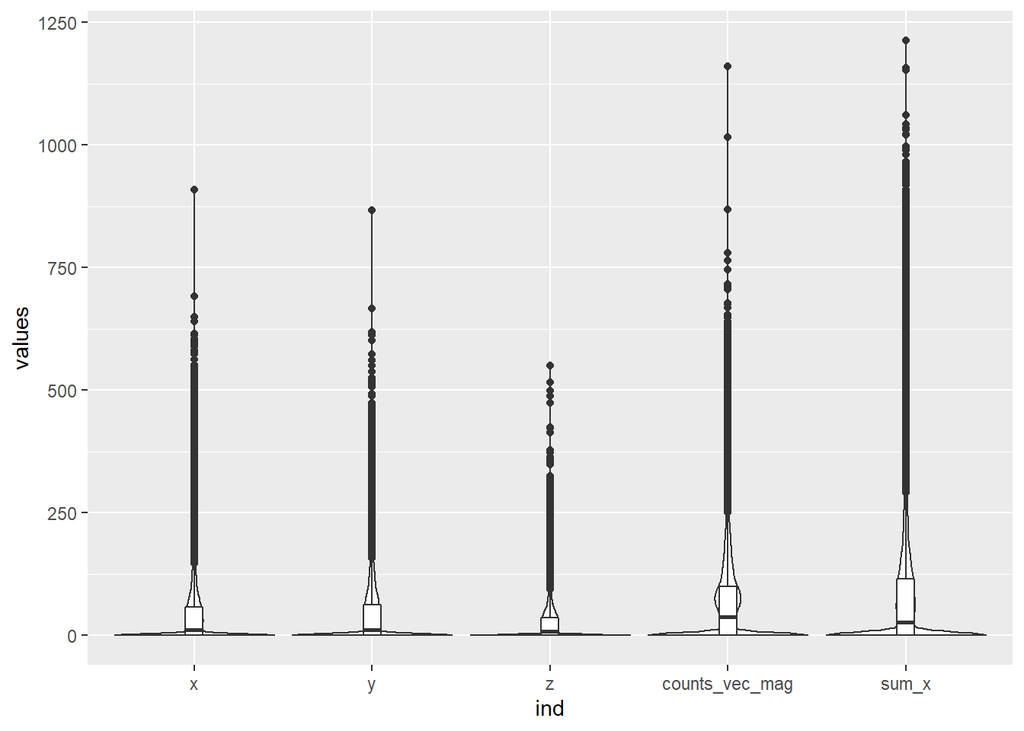

```r
working_df %>%
  select(-c(participant_id,trimmed_activity)) %>%
  select(1:5) %>%
  stack() %>%
  ggplot(aes(x = ind, y = values)) +
  geom_violin(scale = "width") +
  geom_boxplot(width=0.1)
```

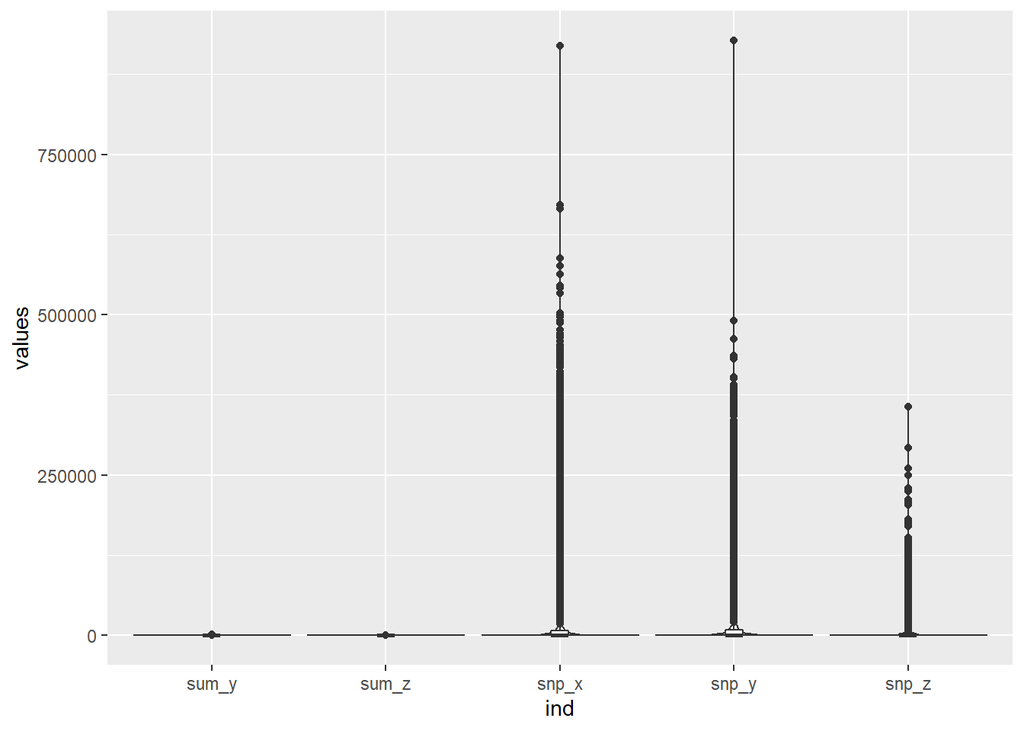

```r
working_df %>%
  select(-c(participant_id,trimmed_activity)) %>%
  select(6:10) %>%
  stack() %>%
  ggplot(aes(x = ind, y = values)) +
  geom_violin(scale = "width") +
  geom_boxplot(width=0.1)
```

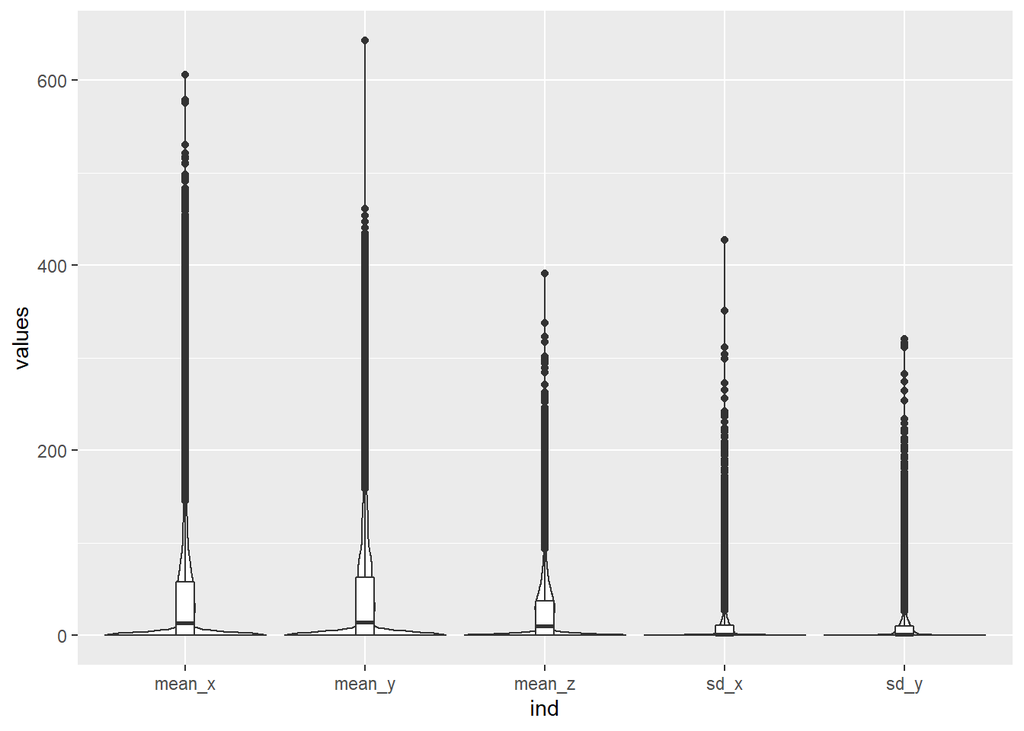

```r
working_df %>%
  select(-c(participant_id,trimmed_activity)) %>%
  select(11:15) %>%
  stack() %>%
  ggplot(aes(x = ind, y = values)) +
  geom_violin(scale = "width") +
  geom_boxplot(width=0.1)
```

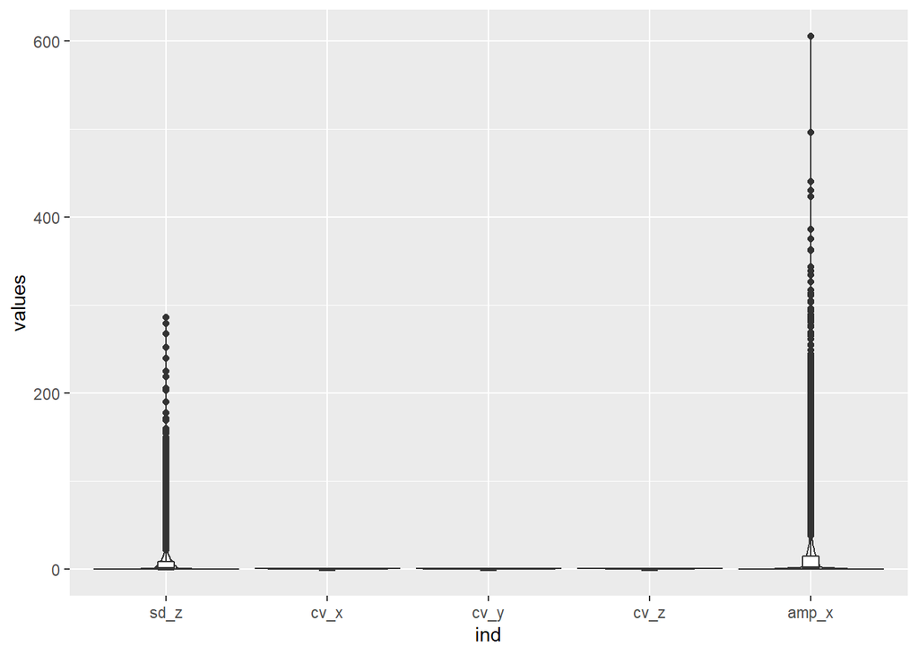

```r
working_df %>%
  select(-c(participant_id,trimmed_activity)) %>%
  select(16:20) %>%
  stack() %>%
  ggplot(aes(x = ind, y = values)) +
  geom_violin(scale = "width") +
  geom_boxplot(width=0.1)
```

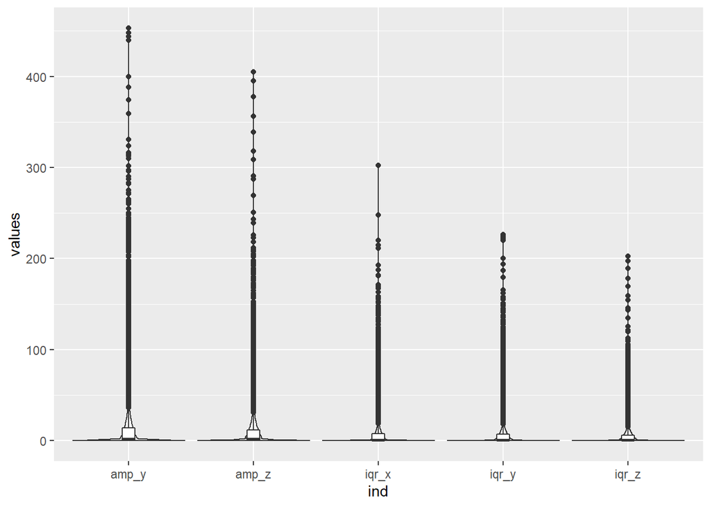

```r
working_df %>%
  select(-c(participant_id,trimmed_activity)) %>%
  select(21:25) %>%
  stack() %>%
  ggplot(aes(x = ind, y = values)) +
  geom_violin(scale = "width") +
  geom_boxplot(width=0.1)
```

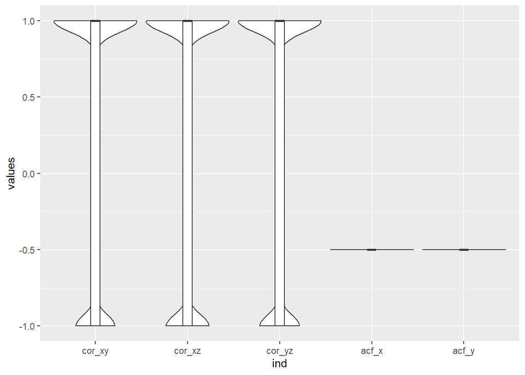

```r
working_df %>%
  select(-c(participant_id,trimmed_activity)) %>%
  select(26:30) %>%
  stack() %>%
  ggplot(aes(x = ind, y = values)) +
  geom_violin(scale = "width") +
  geom_boxplot(width=0.1)
```

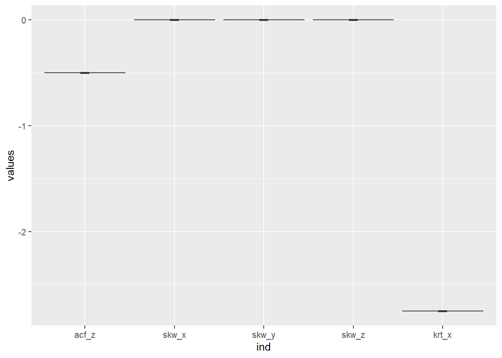

```r
working_df %>%
  select(-c(participant_id,trimmed_activity)) %>%
  select(31:35) %>%
  stack() %>%
  ggplot(aes(x = ind, y = values)) +
  geom_violin(scale = "width") +
  geom_boxplot(width=0.1)
```

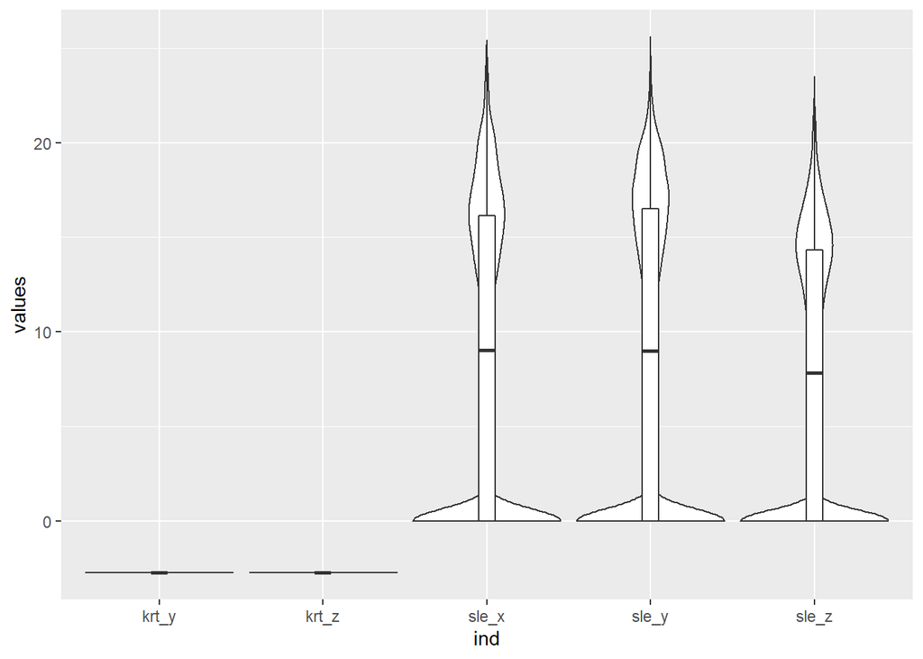

```r
working_df %>%
  select(-c(participant_id,trimmed_activity)) %>%
  select(36:40) %>%
  stack() %>%
  ggplot(aes(x = ind, y = values)) +
  geom_violin(scale = "width") +
  geom_boxplot(width=0.1)
```

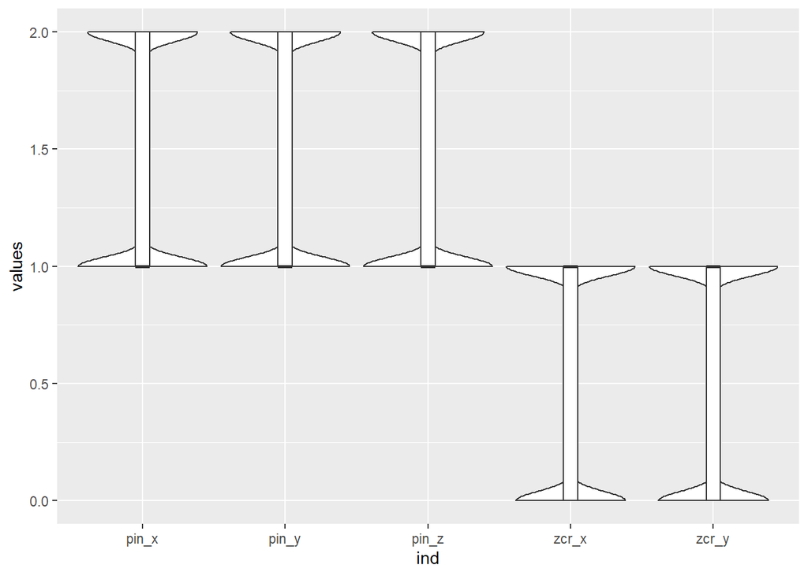

```r
working_df %>%
  select(-c(participant_id,trimmed_activity)) %>%
  select(41:45) %>%
  stack() %>%
  ggplot(aes(x = ind, y = values)) +
  geom_violin(scale = "width") +
  geom_boxplot(width=0.1)
```

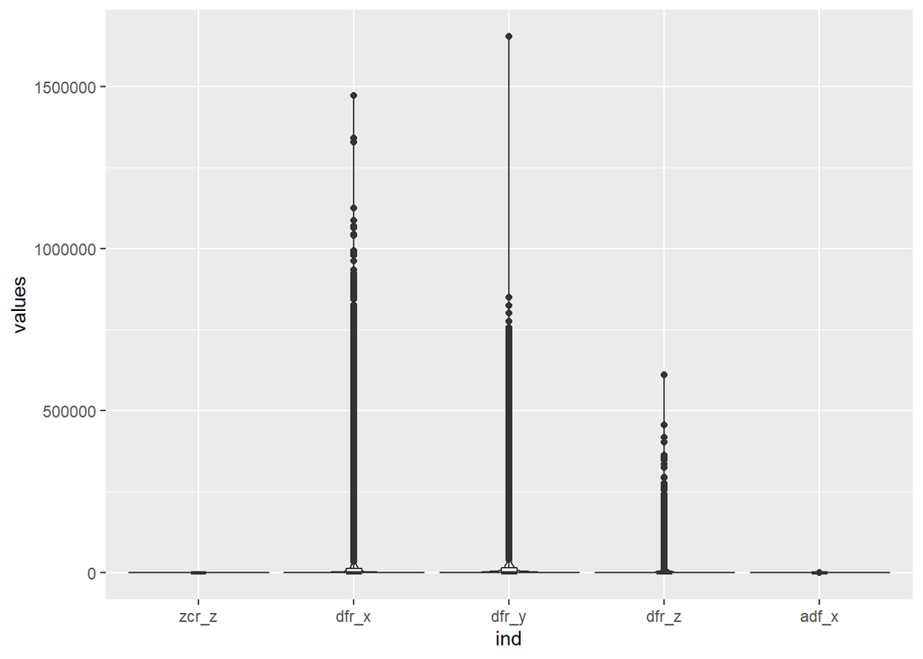

```r
working_df %>%
  select(-c(participant_id,trimmed_activity)) %>%
  select(46:50) %>%
  stack() %>%
  ggplot(aes(x = ind, y = values)) +
  geom_violin(scale = "width") +
  geom_boxplot(width=0.1)
```

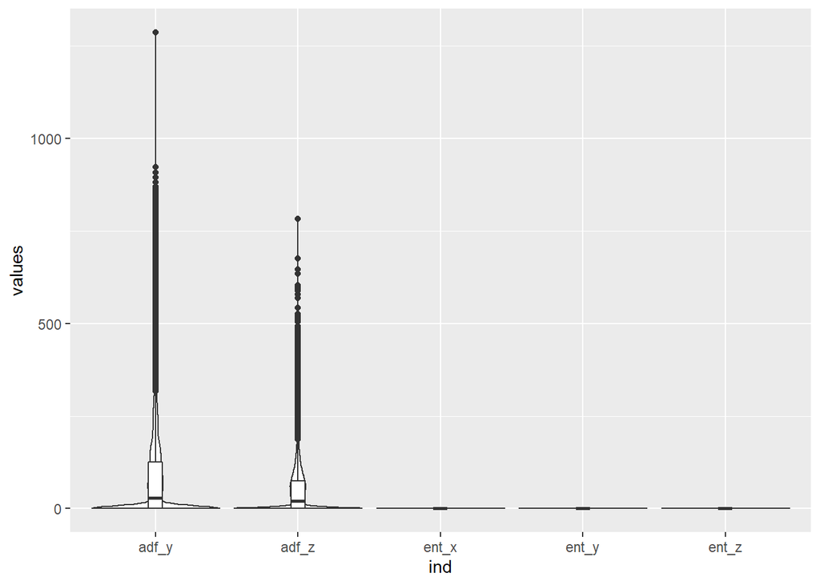

```r
working_df %>%
  select(-c(participant_id,trimmed_activity)) %>%
  select(51:55) %>%
  stack() %>%
  ggplot(aes(x = ind, y = values)) +
  geom_violin(scale = "width") +
  geom_boxplot(width=0.1)
```

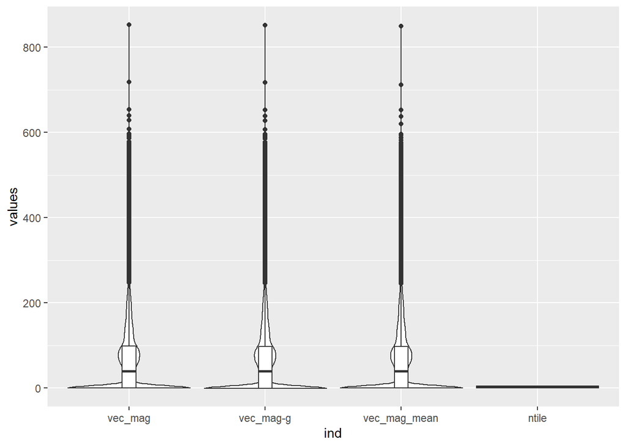

```r
last_column <- ncol(working_df) - 2
working_df %>%
  select(-c(participant_id,trimmed_activity)) %>%
  select(56:last_column) %>%
  stack() %>%
  ggplot(aes(x = ind, y = values)) +
  geom_violin(scale = "width") +
  geom_boxplot(width=0.1)
```

# Plot SD for all features

X axis shows features and y axis shows SD

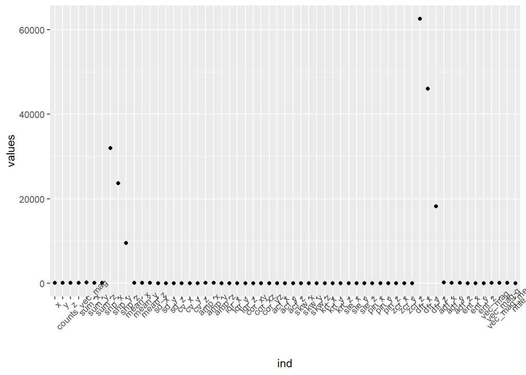

```r
working_df %>%
  select(-c(participant_id,trimmed_activity)) %>%
  summarise_all(sd) %>%
  stack() %>%
  ggplot(aes(x = ind, y = values)) +
  geom_point() +
  theme(axis.text.x = element_text(angle = 45))
```